# Compatibility Effect

## Outline

1. Background: How psychologistis study *Cognitive Conflict*
2. Understand Hommel (2002)
3. Exact replication of Hommel's experiment 1.

## Background: How psychologistis study *Cognitive Conflict*

## Cogintive Conflict

- Awareness of the beliefs, decisions, or behaviors that contradticted with each other.
- A sincere Muslim is not a terrorist.
- A student got F after he had studied over night before the final exam (Cognitive dissonance; Cooper & Fazio, 1984).
- We have to name the color "blue" to the word "red" presented in "blue" (Stroop Effect).
- Summary: [Developed tasks to measure cognitive conflict](http://dimensional-overlap.com/)

## Stimulus-Response Compatibility

[figure not shown]

- Started from Simon and Rudell (1967); Simon(1969).  
- The dimensions of sitmulus are irrelavent to the response set.  
- Compatible responeses are faster than the incompatible responses.

## Understand Hommel (2002)

## Time course of compatibility

- Experiment 1 of Hommel (2002)
- At which *SOA* the space-response compatibility could cause Simon effect.

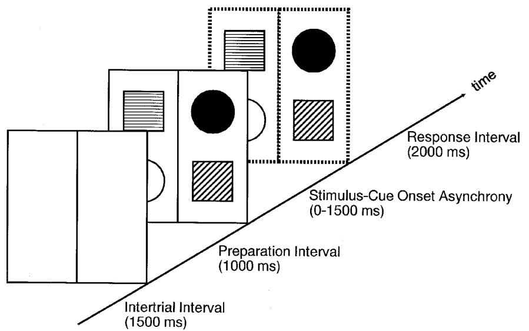

## Original Method

- SOA: A~ 0 ms, 500 ms, 1000 ms, 1500 ms; B~ 0 ms, 250 ms, 500 ms
- Correspondence: Target at corresponding/noncorresponding location.
- Participants: A~ 8 adults; B~ 12 adults.
- Check the Opensesame script.

## Original Resluts

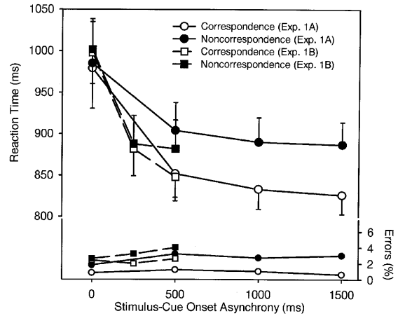

## Original Effect Sizes and Powers, Part A

```
## [1] "ES of SOA = 0.464271152647041"
```

```
## [1] "Power of SOA = 0.409088678303733"
```

```
## [1] "ES of Correspondence = 0.795206225564457"
```

```
## [1] "Power of Correspondence = 0.840525868400419"
```

```
## [1] "ES of Interaction = 0.382970843102535"
```

```
## [1] "Power of Interaction  = 0.297589427142038"
```

## Evluate the power of correspondence (part A) by sample size

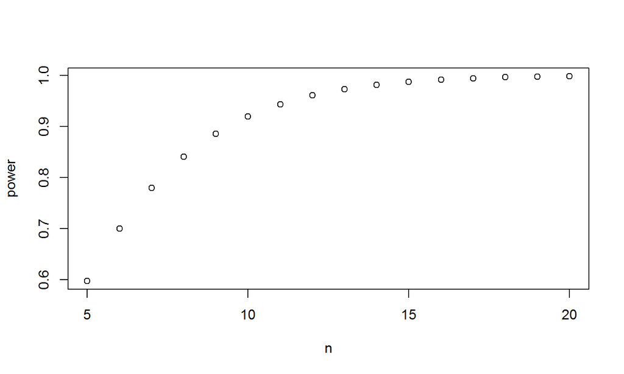

## Original Effect Sizes and Powers, Part B

```
## [1] "ES of SOA = 0.657239966885948"
```

```
## [1] "Power of SOA = 0.867894265162108"
```

```
## [1] "ES of Correspondence = 0.707908035586595"
```

```
## [1] "Power of Correspondence = 0.911993273531602"
```

```
## [1] "ES of Interaction = 0.362786713646082"
```

```
## [1] "Power of Interaction = 0.397470621820526"
```

## Evluate the power of correspondence (part B) by sample size

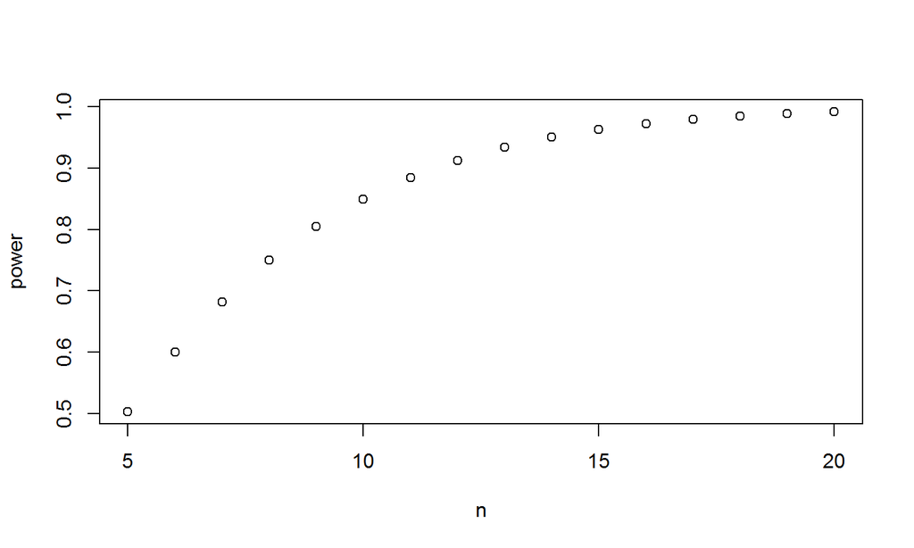

## Exact replication of Hommel's experiment 1

## How to reproduce the experiment

- Execute and check **EXP1A_Draft01.osexp**.
- Check the output file **quickrun.csv**.
- Where are the IVs and DVs (RT, accuracy)?

## Build the executable script

- Complete **EXP1_V01.osexp**.
- Tricks to build an Opensesame script.

**Build functional varibles in each LOOP**  
**Use inline python code out of IVs and DVs**

## How to write the proposal of exact replication?

- Pick up the columns in **quickrun.csv**.
- Describe the functions of columns in this analysis.